# Practical Machine Learning Course Project Report

## By: Brock HUtchings 11/04/2017

The following report was created as an assingment for the practical machine leatninig course from Johns Hopkins university

## Background:

Using devices such as Jawbone Up, Nike FuelBand, and Fitbit it is now possible to collect a large amount of data about personal activity relatively inexpensively. These type of devices are part of the quantified self movement - a group of enthusiasts who take measurements about themselves regularly to improve their health, to find patterns in their behavior, or because they are tech geeks. One thing that people regularly do is quantify how much of a particular activity they do, but they rarely quantify how well they do it. In this project, our goal will be to use data from accelerometers on the belt, forearm, arm, and dumbell of 6 participants. They were asked to perform barbell lifts correctly and incorrectly in 5 different ways. More information is

available from the website here: http://groupware.les.inf.puc-rio.br/har (see the section on the Weight Lifting Exercise Dataset).

## Data Sources:

The training data for this project is available here:  
https://d396qusza40orc.cloudfront.net/predmachlearn/pml-training.csv

The test data is available here:  
https://d396qusza40orc.cloudfront.net/predmachlearn/pml-testing.csv

The data for this project comes from this original source: http://groupware.les.inf.puc-rio.br/har.

## Intended Results:

The goal of this project is to predict the manner in which users performed the exercise.

## Set Up Environment:

#### Install any packagess noton your system

```r
#####  ONLY INSTALL PACKAGES YOU ARE MISSING #########

#install.packages("rattle")

#install.packages("rpart")

#install.packages("rpart.plot")

#install.packages("corrplot")

#install.packages("randomForest")

#install.packages("e1071")
```

#### oad required packages

```r
library(rattle)
library(caret)
```

```r
library(rpart)

library(rpart.plot)

library(corrplot)

library(randomForest)
library(RColorBrewer)
```

#### Load the seed

```r
set.seed(56789)
```

## Get Data:

#### set working directory.

```r
########## YOU WILL HAVE TO CHANGE THE PATH ##########

setwd("C:/Users/BAH/Documents/R_working_directory/Coursework/Machine_Learning")
```

# download the dataset

```r
training_data_URL <- "https://d396qusza40orc.cloudfront.net/predmachlearn/pml-training.csv"

test_data_URL <- "https://d396qusza40orc.cloudfront.net/predmachlearn/pml-testing.csv"

training_file <- "./data/pml-training.csv"

test_file  <- "./data/pml-testing.csv"

#the following if blocks are to prevent replication
if (!file.exists("./data")) {
dir.create("./data")
}

if (!file.exists(training_file)) {
download.file(training_data_URL, destfile = training_file, method = "curl")
}

if (!file.exists(test_file)) {
download.file(test_data_URL, destfile = test_file, method = "curl")
}

#remove url
rm(training_data_URL)

rm(test_data_URL)
```

## Reading Data:

#### read CSVs into dataframes

```r
raw_training_data <- read.csv(training_file)

raw_test_data <- read.csv(test_file)
```

### print the dimensions of raw test dataframes for validation

```r
dim(raw_training_data)
```

```
## [1] 19622   160
```

```r
dim(raw_test_data)
```

```
## [1]  20 160
```

#### remove files that have surved their purpose

```r
rm(training_file)

rm(test_file)
```

## Cleaning Data:

#### create testing and trainig using near zero variance

```r
NZV <- nearZeroVar(raw_training_data, saveMetrics = TRUE)

head(NZV, 20)
```

```
##                        freqRatio percentUnique zeroVar   nzv
## X                       1.000000  100.00000000   FALSE FALSE
## user_name               1.100679    0.03057792   FALSE FALSE
## raw_timestamp_part_1    1.000000    4.26562022   FALSE FALSE
## raw_timestamp_part_2    1.000000   85.53154622   FALSE FALSE
## cvtd_timestamp          1.000668    0.10192641   FALSE FALSE
## new_window             47.330049    0.01019264   FALSE  TRUE
## num_window              1.000000    4.37264295   FALSE FALSE
## roll_belt               1.101904    6.77810621   FALSE FALSE
## pitch_belt              1.036082    9.37722964   FALSE FALSE
## yaw_belt                1.058480    9.97349913   FALSE FALSE
## total_accel_belt        1.063160    0.14779329   FALSE FALSE
## kurtosis_roll_belt   1921.600000    2.02323922   FALSE  TRUE
## kurtosis_picth_belt   600.500000    1.61553358   FALSE  TRUE
## kurtosis_yaw_belt      47.330049    0.01019264   FALSE  TRUE
## skewness_roll_belt   2135.111111    2.01304658   FALSE  TRUE
## skewness_roll_belt.1  600.500000    1.72255631   FALSE  TRUE
## skewness_yaw_belt      47.330049    0.01019264   FALSE  TRUE
## max_roll_belt           1.000000    0.99378249   FALSE FALSE
## max_picth_belt          1.538462    0.11211905   FALSE FALSE
## max_yaw_belt          640.533333    0.34654979   FALSE  TRUE
```

```r
training1 <- raw_training_data[, !NZV$nzv]

testing1 <- raw_test_data[, !NZV$nzv]
```

#### pringt dimensions of training1 and testing1 for confirmation

```r
dim(training1)
```

```
## [1] 19622   100
```

```r
dim(testing1)
```

```
## [1]  20 100
```

```r
rm(raw_training_data)

rm(raw_test_data)

rm(NZV)
```

#### removing columns that are not part of the accelerometer measurements

```r
regex <- grepl("^X|timestamp|user_name", names(training1))

training <- training1[, !regex]

testing <- testing1[, !regex]
```

#### get the dimensions of testing and training for confirmation

```r
dim(training)
```

```
## [1] 19622    95
```

```r
dim(testing)
```

```
## [1] 20 95
```

#### remove unneeded elements

```r
rm(regex)

rm(training1)

rm(testing1)
```

# removing columns that contain na values

```r
cond <- (colSums(is.na(training)) == 0)

training <- training[, cond]

testing <- testing[, cond]
```

#### remove undneeded element

```r
rm(cond)
```

If all the above steps were completed sucessfully we should have a clean data set and be ready for analysis and generation of visual representations.

#### generate correlation plot

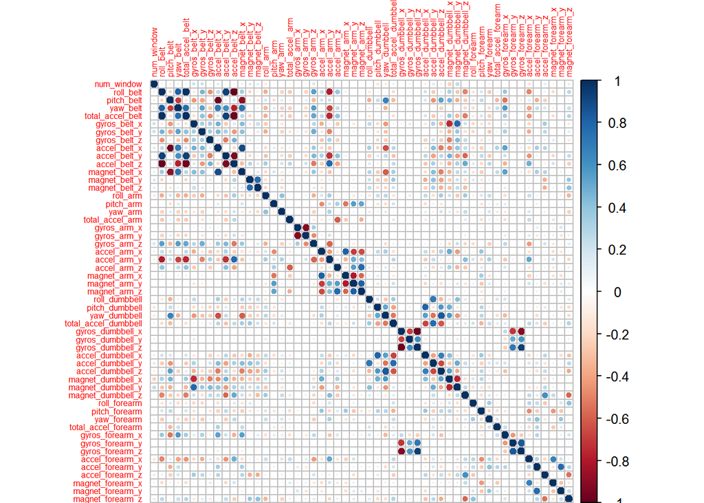

```r
corrplot(cor(training[, -length(names(training))]), tl.cex = 0.5)
```

## Partition Training Set:

We have split the trainng set that has been cleaned into two segments one 30% validation set and one 70% trainig set. We will now use the validation set to do cross comparisons.

#### split training

```r
set.seed(56789) # For reproducibile purpose

inTrain <- createDataPartition(training$classe, p = 0.70, list = FALSE)

validation <- training[-inTrain, ]

training <- training[inTrain, ]
```

#### remove undeeded element

```r
rm(inTrain)
```

## Data Modelling

### Decision Tree:

#### createa decision tree

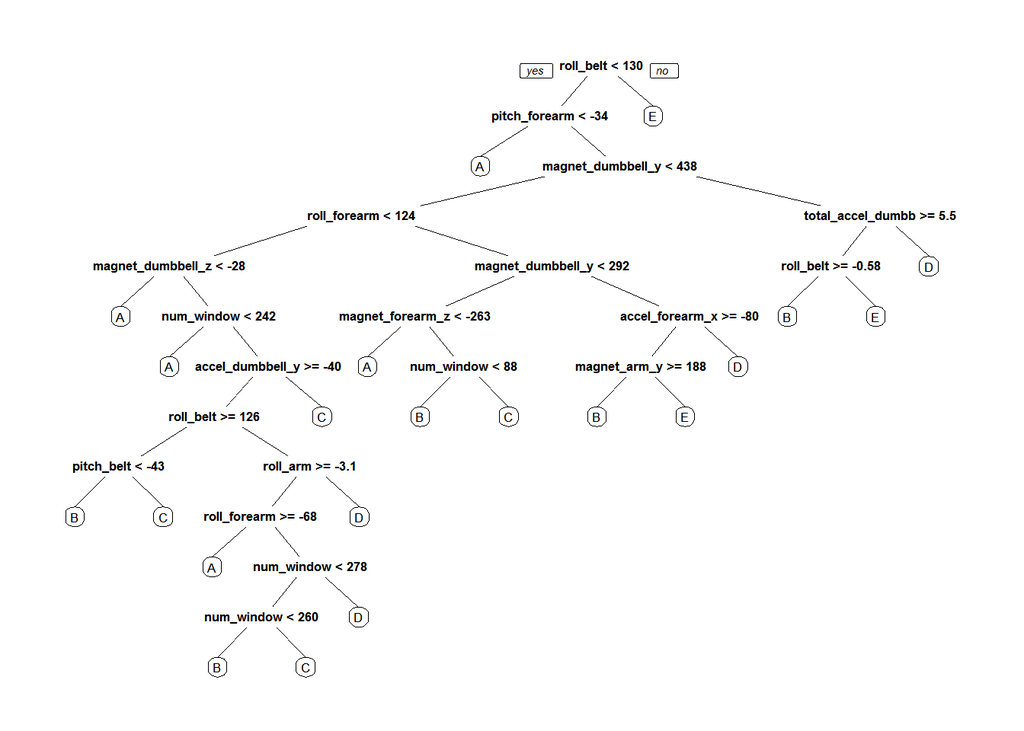

```r
tree <- rpart(classe ~ ., data = training, method = "class")

prp(tree)
```

The next step is to estimate the performance of the model base don the validation of the data set.

#### perform evaluation

```r
prediction_tree <- predict(tree, validation, type = "class")

confusionMatrix(validation$classe, prediction_tree)
```

```
## Confusion Matrix and Statistics
##
##           Reference
## Prediction    A    B    C    D    E
##          A 1526   41   20   61   26
##          B  264  646   74  126   29
##          C   20   56  852   72   26
##          D   93   31  133  665   42
##          E   82   85   93  128  694
##
## Overall Statistics
##
##                Accuracy : 0.7448
##                  95% CI : (0.7334, 0.7559)
##     No Information Rate : 0.3373
##     P-Value [Acc > NIR] : < 2.2e-16
##
##                   Kappa : 0.6754
##  Mcnemar's Test P-Value : < 2.2e-16
##
## Statistics by Class:
##
##                      Class: A Class: B Class: C Class: D Class: E
## Sensitivity            0.7688   0.7520   0.7270   0.6321   0.8494
## Specificity            0.9621   0.9019   0.9631   0.9381   0.9234
## Pos Pred Value         0.9116   0.5672   0.8304   0.6898   0.6414
## Neg Pred Value         0.8910   0.9551   0.9341   0.9214   0.9744
## Prevalence             0.3373   0.1460   0.1992   0.1788   0.1388
## Detection Rate         0.2593   0.1098   0.1448   0.1130   0.1179
## Detection Prevalence   0.2845   0.1935   0.1743   0.1638   0.1839
## Balanced Accuracy      0.8654   0.8270   0.8450   0.7851   0.8864
```

```r
accuracy <- postResample(prediction_tree, validation$classe)

ose <- 1 - as.numeric(confusionMatrix(validation$classe, prediction_tree)$overall[1])
```

#### Remove elements that are no longer needed

```r
rm(prediction_tree)

rm(tree)
```

### Random Forest:

I chose to use a random forest due to its abilities to automatically select key variables.

#### perform evaluation

```r
random_forest_model <- train(classe ~ ., data = training, method = "rf", trControl = trainControl(method = "cv", 5), ntree = 250)

#show model
random_forest_model
```

```
## Random Forest
##
## 13737 samples
##    53 predictor
##     5 classes: 'A', 'B', 'C', 'D', 'E'
##
## No pre-processing
## Resampling: Cross-Validated (5 fold)
## Summary of sample sizes: 10989, 10988, 10991, 10990, 10990
## Resampling results across tuning parameters:
##
##   mtry  Accuracy   Kappa
##    2    0.9941763  0.9926330
##   27    0.9966511  0.9957639
##   53    0.9948310  0.9934612
##
## Accuracy was used to select the optimal model using  the largest value.
## The final value used for the model was mtry = 27.
```

#### predict random forest

```r
predict_random_forest <- predict(random_forest_model, validation)

confusionMatrix(validation$classe, predict_random_forest)
```

```
## Confusion Matrix and Statistics
##
##           Reference
## Prediction    A    B    C    D    E
##          A 1674    0    0    0    0
##          B    3 1136    0    0    0
##          C    0    1 1022    3    0
##          D    0    0    3  961    0
##          E    0    0    0    1 1081
##
## Overall Statistics
##
##                Accuracy : 0.9981
##                  95% CI : (0.9967, 0.9991)
##     No Information Rate : 0.285
##     P-Value [Acc > NIR] : < 2.2e-16
##
##                   Kappa : 0.9976
##  Mcnemar's Test P-Value : NA
##
## Statistics by Class:
##
##                      Class: A Class: B Class: C Class: D Class: E
## Sensitivity            0.9982   0.9991   0.9971   0.9959   1.0000
## Specificity            1.0000   0.9994   0.9992   0.9994   0.9998
## Pos Pred Value         1.0000   0.9974   0.9961   0.9969   0.9991
## Neg Pred Value         0.9993   0.9998   0.9994   0.9992   1.0000
## Prevalence             0.2850   0.1932   0.1742   0.1640   0.1837
## Detection Rate         0.2845   0.1930   0.1737   0.1633   0.1837
## Detection Prevalence   0.2845   0.1935   0.1743   0.1638   0.1839
## Balanced Accuracy      0.9991   0.9992   0.9981   0.9976   0.9999
```

```r
accuracy <- postResample(predict_random_forest, validation$classe)

ose <- 1 - as.numeric(confusionMatrix(validation$classe, predict_random_forest)$overall[1])
```

#### remove unneeded element

```r
rm(predict_random_forest)
```

As can be seen from the above output the random forest produced better results than expected

## Predict The Type of Exercise Fot Test Set

In the following section i applied the reandom forest model to the origional testing data set. The only real change was that the unwanted column was removed prior.

#### remove unwanted column

```r
rm(accuracy)

rm(ose)
```

#### perform prediction

```r
predict(random_forest_model, testing[, -length(names(testing))])
```

```
##  [1] B A B A A E D B A A B C B A E E A B B B
## Levels: A B C D E
```

## Generating Files to submit for marking:

#### generate required files for submission

```r
pml_write_files = function(x){
  n = length(x)

  for(i in 1:n){
    filename = paste0("./Assignment_Solutions/problem_id_",i,".txt")

    write.table(x[i], file = filename, quote = FALSE, row.names = FALSE,
                col.names = FALSE)
  }
}
```

#### generate files

```r
pml_write_files(predict(random_forest_model, testing[, -length(names(testing))]))
```

#### remove uneccesary elements

```r
rm(random_forest_model)
rm(training)
rm(testing)
rm(validation)
rm(pml_write_files)
```